# 2020 JBER Final Report Analysis

Jeff Wagner

## Statewide collared pika (*Ochotona collaris*) surveys in Alaska: summary analysis for Joint Base Elmendorf-Richardson

#### Data collected July - Sep 2018 and July - Aug 2019

#### Field team consisted of University of Alaska Anchorage, Alaska Center for Conservation Science (ACCS) personnel: Paul Schuette, Amanda Droghini, Jeff Wagner, Rachel Kelty, Lindsey Taylor, Logan Suiter

```r
rm(list = ls())

library(tidyverse)
library(readxl)
library(unmarked)
library(lubridate)
library(pivottabler)
library(doBy)
library(egg)
```

### Part 1: Load the observation data

```r
#Load all sheets in the workbook
path <- "./data/2018_and_2019_observation_data.xlsx"

#Load the observation data
observations <- read_excel(path=path, sheet="Observations")
```

```
## * `` -> ...25
## * `` -> ...26
## * `` -> ...27
## * `` -> ...28
## * `` -> ...29
## * … and 2 more problems
```

```r
head(observations)
```

```
## # A tibble: 6 x 31
##   Org   Location Site   Year visit_type Observer GPS_Unit Species WP    Obs_Type
##   <chr> <chr>    <chr> <dbl> <chr>      <chr>       <dbl> <chr>   <chr> <chr>
## 1 ACCS  Denali   MV     2018 i          AD             27 PIKA    199   feces
## 2 ACCS  Denali   MV     2018 i          AD             27 VOLE    199   feces
## 3 ACCS  Denali   MV     2018 i          AD             27 AGS     199   visual
## 4 ACCS  Denali   MV     2018 i          AD             27 AGS     199   visual
## 5 ACCS  Denali   MV     2018 i          AD             27 AGS     199   visual
## 6 ACCS  Denali   MV     2018 i          AD             27 PIKA    200   feces
## # … with 21 more variables: Freshness <chr>, Sample <chr>, Dist_veg_m <chr>,
## #   Veg_type <chr>, Color <chr>, Size_L_cm <chr>, Size_W_cm <chr>,
## #   Size_H_cm <chr>, Transect_bearing <chr>, Animal_bearing <chr>,
## #   Dist_animal_m <chr>, Count <chr>, Audio <chr>, Notes <chr>, ...25 <lgl>,
## #   ...26 <lgl>, ...27 <lgl>, ...28 <lgl>, ...29 <lgl>, ...30 <lgl>,
## #   ...31 <lgl>
```

```r
observations <- as.data.frame(observations)
head(observations)
```

```
##    Org Location Site Year visit_type Observer GPS_Unit Species  WP Obs_Type
## 1 ACCS   Denali   MV 2018          i       AD       27    PIKA 199    feces
## 2 ACCS   Denali   MV 2018          i       AD       27    VOLE 199    feces
## 3 ACCS   Denali   MV 2018          i       AD       27     AGS 199   visual
## 4 ACCS   Denali   MV 2018          i       AD       27     AGS 199   visual
## 5 ACCS   Denali   MV 2018          i       AD       27     AGS 199   visual
## 6 ACCS   Denali   MV 2018          i       AD       27    PIKA 200    feces
##   Freshness Sample Dist_veg_m Veg_type Color Size_L_cm Size_W_cm Size_H_cm
## 1        NA      Y         NA       NA     B        NA        NA        NA
## 2        NA      Y         NA       NA     B        NA        NA        NA
## 3        NA     NA         NA       NA    NA        NA        NA        NA
## 4        NA     NA         NA       NA    NA        NA        NA        NA
## 5        NA     NA         NA       NA    NA        NA        NA        NA
## 6        NA      Y         NA       NA     B        NA        NA        NA
##   Transect_bearing Animal_bearing Dist_animal_m Count Audio Notes ...25 ...26
## 1               NA             NA            NA    NA    NA  <NA>    NA    NA
## 2               NA             NA            NA    NA    NA  <NA>    NA    NA
## 3              126            126            17     1     Y  <NA>    NA    NA
## 4              126            260            30     1     Y  <NA>    NA    NA
## 5              126            198            21     1     Y  <NA>    NA    NA
## 6               NA             NA            NA    NA    NA  <NA>    NA    NA
##   ...27 ...28 ...29 ...30 ...31
## 1    NA    NA    NA    NA    NA
## 2    NA    NA    NA    NA    NA
## 3    NA    NA    NA    NA    NA
## 4    NA    NA    NA    NA    NA
## 5    NA    NA    NA    NA    NA
## 6    NA    NA    NA    NA    NA
```

```r
#only include initial visits (no revisits) and let's focus on pika only
unique(observations$Species)  #Make sure PIKA doesn't have any misspellings and see which species we have data
```

```
##  [1] "PIKA"  "VOLE"  "AGS"   "HOMA"  "MAR"   "UNK"   "SHEEP" "MOUSE" "BEAR"
## [10] "HARE"  "PTARM" "UNG"   "WOLF"  "MARM"  "PTAR"  "CAR"   "OWL"
```

```r
observations$Species <- observations$Species %>%
  recode("MAR" = "HOMA", "MARM" = "HOMA", "CAR" = "HOMA", "PTAR" = "PTARM")
```

Arrange by site name: want to view the JBER sites. We only have JBER data collected by JW, PS, and Colette Brandt (CB) in here so want to treat this as an ‘initial visit’ with our complete methods. We will remove the ‘revisit’ data to other sites for now and want to make sure we include our 2019 JBER data:

```r
observations <- observations %>%
  arrange(Site)

observations <- observations %>%
  mutate(visit_type = ifelse(Location == "JBER", "i", visit_type))
```

Sort by visit_type to confirm the other sites listed as revisits; we want to exclude those for now:

```r
observations %>%
  arrange(desc(visit_type))  # yes, only P007 and P008 were revisited so we will exclude those next.
```

```
##       Org      Location       Site Year visit_type       Observer GPS_Unit
## 1    ACCS  Hatcher Pass       P007 2018          r             JW       45
## 2    ACCS  Hatcher Pass       P007 2018          r             JW       45
## 3    ACCS  Hatcher Pass       P007 2018          r             JW       45
## 4    ACCS  Hatcher Pass       P007 2018          r             JW       45
## 5    ACCS  Hatcher Pass       P007 2018          r             JW       45
## 6    ACCS  Hatcher Pass       P007 2018          r             JW       45
## 7    ACCS  Hatcher Pass       P007 2018          r             JW       45
## 8    ACCS  Hatcher Pass       P007 2018          r             JW       45
## 9    ACCS  Hatcher Pass       P007 2018          r             JW       45
## 10   ACCS  Hatcher Pass       P007 2018          r             JW       45
## 11   ACCS  Hatcher Pass       P007 2018          r             JW       45
## 12   ACCS  Hatcher Pass       P007 2018          r             JW       45
## 13   ACCS  Hatcher Pass       P007 2018          r             JW       45
## 14   ACCS  Hatcher Pass       P007 2018          r             JW       45
```

[output cut: 13695 more lines]

Simplify the data frame by selecting the columns of interest and selecting only the initial surveys (exclude P007 and P008 revisits):

```r
obs <- observations %>%
  select(Location, Site, Year, visit_type, Observer, Species, Obs_Type, Freshness, Sample, Color, Count, Audio) %>%
  filter(visit_type == 'i')
```

Subset this list of observations into categories to make things easier to work with later:

```r
#Pika observations only
pika.obs <- obs %>%
  filter(Species == 'PIKA')

#JBER observations only
JBER.obs <- obs %>%
  filter(Location == 'JBER')

#JBER pika observations only
JBER.pika.obs <- pika.obs %>%
  filter(Location == 'JBER')
```

### Part 2: JBER Haypile Sample Summary

##### Here we are interested in how many haypiles we encountered per site and of those, how many contained fresh vegetation (indicative of recent pika activity).

Filter JBER haypile observations only:

```r
JBER.haypile.obs <- JBER.pika.obs %>%
  filter(Obs_Type == 'haypile')
```

Cleanup the data - create new column for freshness based on haypile colors:

```r
JBER.haypile.obs$Freshness <- JBER.haypile.obs$Color %>%
  recode("B" = "Old", "G" = "Fresh", "GB" = "Fresh and Old", "NA" = "Old")
```

Create a pivot table to summarize JBER haypiles:

```r
pt <- PivotTable$new()
pt$addData(JBER.haypile.obs)
pt$addColumnDataGroups("Site")
pt$addRowDataGroups("Freshness")
pt$defineCalculation(calculationName = "TotalHaypiles", summariseExpression = "n()")
pt$evaluatePivot()
(haypile.pivot <- pt$asDataFrame())
```

```
##               JB01 JB02 Total
## Fresh            1    4     5
## Fresh and Old    2    9    11
## Old             14   10    24
## Total           17   23    40
```

Create a table to calculate summary statistics:

```r
(haypile.summary <- as.data.frame(t(haypile.pivot[,1:2]), drop=false))
```

```
##      Fresh Fresh and Old Old Total
## JB01     1             2  14    17
## JB02     4             9  10    23
```

#### Summary statistics

Mean number of total haypiles per site:

```r
std <- function(x) sd(x)/sqrt(length(x))

mean(haypile.summary$Total)
```

```
## [1] 20
```

```r
sd(haypile.summary$Total)
```

```
## [1] 4.242641
```

```r
std(haypile.summary$Total)
```

```
## [1] 3
```

Mean number of fresh haypiles per site:

```r
haypile.summary$Contains_fresh <- haypile.summary$Fresh + haypile.summary$`Fresh and Old`

mean(haypile.summary$Contains_fresh)
```

```
## [1] 8
```

```r
sd(haypile.summary$Contains_fresh)
```

```
## [1] 7.071068
```

```r
std(haypile.summary$Contains_fresh)
```

```
## [1] 5
```

Number of haypile samples collected:

```r
(haypile.samples <- filter(JBER.haypile.obs, Sample == "Y"))
```

```
##   Location Site Year visit_type Observer Species Obs_Type     Freshness Sample
## 1     JBER JB01 2019          i       CB    PIKA  haypile Fresh and Old      Y
## 2     JBER JB01 2019          i       CB    PIKA  haypile         Fresh      Y
## 3     JBER JB02 2019          i       CB    PIKA  haypile Fresh and Old      Y
## 4     JBER JB02 2019          i       CB    PIKA  haypile Fresh and Old      Y
## 5     JBER JB02 2019          i       JW    PIKA  haypile Fresh and Old      Y
## 6     JBER JB02 2019          i       JW    PIKA  haypile         Fresh      Y
## 7     JBER JB02 2019          i       PS    PIKA  haypile Fresh and Old      Y
## 8     JBER JB02 2019          i       PS    PIKA  haypile         Fresh      Y
## 9     JBER JB02 2019          i       PS    PIKA  haypile         Fresh      Y
##   Color Count Audio
## 1    GB    NA    NA
## 2     G    NA    NA
## 3    GB    NA    NA
## 4    GB    NA    NA
## 5    GB    NA    NA
## 6     G    NA    NA
## 7    GB    NA    NA
## 8     G    NA    NA
## 9     G    NA    NA
```

```r
summaryBy(Obs_Type~Site, data = haypile.samples, FUN = length)
```

```
##   Site Obs_Type.length
## 1 JB01               2
## 2 JB02               7
```

### Part 3: JBER Fecal Sample Summary

##### Here we are interested in how many pika fecal samples we encountered per site and of those, how many were fresh (indicative of recent pika activity). It should be noted that since pikas are coprophagic, distinguishing between fresh and old fecal pellets can be difficult.

Filter JBER fecal observations only - separate out pika observations and observations of all species:

```r
JBER.fecal.all <- JBER.obs %>%
  filter(Obs_Type == 'feces')

JBER.fecal.obs <- JBER.pika.obs %>%
  filter(Obs_Type == 'feces')
```

Clean up the data - rename freshness codes:

```r
JBER.fecal.obs$Freshness <- JBER.fecal.obs$Freshness %>%
  recode("O" = "Old", "F" = "Fresh", "FO" = "Indistinguishable")
```

Create a pivot table of fecal samples:

```r
pt <- PivotTable$new()
pt$addData(JBER.fecal.obs)
pt$addColumnDataGroups("Site")
pt$addRowDataGroups("Freshness")
pt$defineCalculation(calculationName = "TotalFecal", summariseExpression = "n()")
pt$evaluatePivot()
cat(pt$getLatex())
```

```
## \begin{table}[h!]
##   \centering
##   \begin{tabular}{|l|rrr|}
##     \hline
##     & JB01 & JB02 & Total\\
##     \hline
##     Fresh  &  & 3 & 3\\
##     Indistinguishable  &  & 2 & 2\\
##     Old  & 21 & 13 & 34\\
##     Total  & 21 & 18 & 39\\
##     \hline
##   \end{tabular}
## \end{table}
```

```r
(fecal.pivot <- pt$asDataFrame())
```

```
##                   JB01 JB02 Total
## Fresh               NA    3     3
## Indistinguishable   NA    2     2
## Old                 21   13    34
## Total               21   18    39
```

Coerce NA values to 0:

```r
fecal.pivot[is.na(fecal.pivot)] <- 0
fecal.pivot
```

```
##                   JB01 JB02 Total
## Fresh                0    3     3
## Indistinguishable    0    2     2
## Old                 21   13    34
## Total               21   18    39
```

Create a table for summary statistics:

```r
(fecal.summary <- as.data.frame(t(fecal.pivot[,1:2]), drop=false))
```

```
##      Fresh Indistinguishable Old Total
## JB01     0                 0  21    21
## JB02     3                 2  13    18
```

#### Summary statistics

Mean number of total pika fecal samples per site:

```r
mean(fecal.summary$Total)
```

```
## [1] 19.5
```

```r
sd(fecal.summary$Total)
```

```
## [1] 2.12132
```

```r
std(fecal.summary$Total)
```

```
## [1] 1.5
```

Mean number of fresh pika fecal samples per site:

```r
mean(fecal.summary$Fresh)
```

```
## [1] 1.5
```

```r
sd(fecal.summary$Fresh)
```

```
## [1] 2.12132
```

```r
std(fecal.summary$Fresh)
```

```
## [1] 1.5
```

Number of pika fecal samples collected:

```r
(fecal.samples <- filter(JBER.fecal.obs, Sample == "Y"))
```

```
##    Location Site Year visit_type Observer Species Obs_Type         Freshness
## 1      JBER JB01 2019          i       CB    PIKA    feces               Old
## 2      JBER JB01 2019          i       CB    PIKA    feces               Old
## 3      JBER JB01 2019          i       CB    PIKA    feces               Old
## 4      JBER JB01 2019          i       PS    PIKA    feces               Old
## 5      JBER JB01 2019          i       PS    PIKA    feces               Old
## 6      JBER JB02 2019          i       CB    PIKA    feces               Old
## 7      JBER JB02 2019          i       CB    PIKA    feces               Old
## 8      JBER JB02 2019          i       JW    PIKA    feces             Fresh
## 9      JBER JB02 2019          i       JW    PIKA    feces             Fresh
## 10     JBER JB02 2019          i       PS    PIKA    feces Indistinguishable
## 11     JBER JB02 2019          i       PS    PIKA    feces             Fresh
## 12     JBER JB02 2019          i       PS    PIKA    feces Indistinguishable
##    Sample Color Count Audio
## 1       Y    NA    NA    NA
## 2       Y    NA    NA    NA
## 3       Y    NA    NA    NA
## 4       Y    NA    NA    NA
## 5       Y    NA    NA    NA
## 6       Y    NA    NA    NA
## 7       Y    NA    NA    NA
## 8       Y    NA    NA    NA
## 9       Y    NA    NA    NA
## 10      Y    NA    NA    NA
## 11      Y    NA    NA    NA
## 12      Y    NA    NA    NA
```

```r
summaryBy(Obs_Type~Site, data = fecal.samples, FUN = length)
```

```
##   Site Obs_Type.length
## 1 JB01               5
## 2 JB02               7
```

### Part 4: JBER Visual Observation Summary

Filter JBER visual observations only - separate out pika observations and observations of all species:

```r
JBER.visual.all <- JBER.obs %>%
  filter(Obs_Type == 'visual')

JBER.visual.obs <- JBER.pika.obs %>%
  filter(Obs_Type == 'visual')
```

Clean up observation type names:

```r
JBER.visual.obs$Obs_Type <- JBER.visual.obs$Obs_Type %>%
  recode("visual" = "Visual")
```

Create a pivot table of visual observations for all species:

```r
pt <- PivotTable$new()
pt$addData(JBER.visual.all)
pt$addColumnDataGroups("Site")
pt$addRowDataGroups("Species")
pt$defineCalculation(calculationName = "TotalVisual", summariseExpression = "n()")
pt$evaluatePivot()
cat(pt$getLatex())
```

```
## \begin{table}[h!]
##   \centering
##   \begin{tabular}{|l|rrr|}
##     \hline
##     & JB01 & JB02 & Total\\
##     \hline
##     AGS  & 1 & 3 & 4\\
##     PIKA  & 1 & 5 & 6\\
##     Total  & 2 & 8 & 10\\
##     \hline
##   \end{tabular}
## \end{table}
```

```r
(visual.pivot <- pt$asDataFrame())
```

```
##       JB01 JB02 Total
## AGS      1    3     4
## PIKA     1    5     6
## Total    2    8    10
```

Create a table to calculate summary statistics:

```r
(visual.summary <- as.data.frame(t(visual.pivot[1:3,1:2]), drop=false))
```

```
##      AGS PIKA Total
## JB01   1    1     2
## JB02   3    5     8
```

#### Summary statistics

Mean number of pika observations per site:

```r
mean(visual.summary$PIKA)
```

```
## [1] 3
```

```r
sd(visual.summary$PIKA)
```

```
## [1] 2.828427
```

```r
std(visual.summary$PIKA)
```

```
## [1] 2
```

Mean number of AGS observations per site:

```r
mean(visual.summary$AGS)
```

```
## [1] 2
```

```r
sd(visual.summary$AGS)
```

```
## [1] 1.414214
```

```r
std(visual.summary$AGS)
```

```
## [1] 1
```

### Part 5: JBER Haypile Vegetation Summary

Import haypile ID data:

```r
JBER.haypile.veg <- read_csv("./data/JBERHaypiles2019.csv")
factor(JBER.haypile.veg$functionalGroup)
```

```
##   [1] Forb              Forb              Forb              Forb
##   [5] Forb              Forb              Forb              Forb
##   [9] Forb              Dwarf shrub       Dwarf shrub       Forb
##  [13] Forb              Forb              Forb              Forb
##  [17] Forb              Dwarf shrub       Dwarf shrub       Forb
##  [21] Forb              Forb              Forb              Forb
##  [25] Dwarf shrub       Dwarf shrub       Dwarf shrub       Dwarf shrub
##  [29] Dwarf shrub       Dwarf shrub       Dwarf shrub       Dwarf shrub
##  [33] Dwarf shrub       Dwarf shrub       Dwarf shrub       Dwarf shrub
##  [37] Dwarf shrub       Dwarf shrub       Dwarf shrub       Ferns and Allies
##  [41] Forb              Forb              Forb              Forb
##  [45] Forb              Forb              Forb              Forb
##  [49] Forb              Forb              Forb              Forb
##  [53] Forb              Forb              Forb              Forb
##  [57] Forb              Forb              Forb              Graminoid
```

[output cut: 21 more lines]

Create table summarizing the functional groups:

```r
(JBER.haypile.freq <- count_(JBER.haypile.veg, 'functionalGroup'))
```

```
## # A tibble: 6 x 2
##   functionalGroup       n
##   <chr>             <int>
## 1 Bryoid Herbacious    13
## 2 Dwarf shrub          41
## 3 Ferns and Allies      2
## 4 Forb                 60
## 5 Graminoid             9
## 6 <NA>                 13
```

Get rid of the NA row for samples that couldn’t be identified to the funtional group level:

```r
(JBER.haypile.freq <- slice(JBER.haypile.freq, 1:5))
```

```
## # A tibble: 5 x 2
##   functionalGroup       n
##   <chr>             <int>
## 1 Bryoid Herbacious    13
## 2 Dwarf shrub          41
## 3 Ferns and Allies      2
## 4 Forb                 60
## 5 Graminoid             9
```

Prepare data for plotting - reorder by frequency:

```r
colnames(JBER.haypile.freq) <- c("Functional Group", "Frequency")  # change column names
JBER.haypile.freq <- JBER.haypile.freq[order(JBER.haypile.freq$Frequency), ]  # sort
JBER.haypile.freq$`Functional Group` <- factor(JBER.haypile.freq$`Functional Group`, levels = JBER.haypile.freq$`Functional Group`)  # to retain the order in plot
head(JBER.haypile.freq)
```

```
## # A tibble: 5 x 2
##   `Functional Group` Frequency
##   <fct>                  <int>
## 1 Ferns and Allies           2
## 2 Graminoid                  9
## 3 Bryoid Herbacious         13
## 4 Dwarf shrub               41
## 5 Forb                      60
```

Convert to proportions (125 identifiable samples total):

```r
JBER.haypile.freq$Proportion <- JBER.haypile.freq$Frequency/125
head(JBER.haypile.freq)
```

```
## # A tibble: 5 x 3
##   `Functional Group` Frequency Proportion
##   <fct>                  <int>      <dbl>
## 1 Ferns and Allies           2      0.016
## 2 Graminoid                  9      0.072
## 3 Bryoid Herbacious         13      0.104
## 4 Dwarf shrub               41      0.328
## 5 Forb                      60      0.48
```

Plot the results:

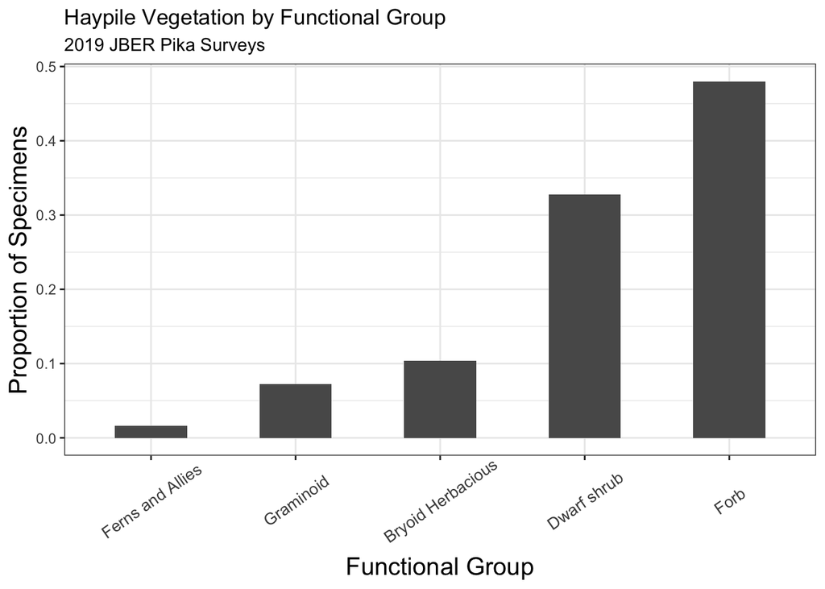

```r
theme_set(theme_bw())

ggplot(JBER.haypile.freq, aes(x=JBER.haypile.freq$`Functional Group`, y=Proportion)) +
  geom_bar(stat="identity", width=.5) +
  labs(title="Haypile Vegetation by Functional Group",
       subtitle="2019 JBER Pika Surveys") +
  xlab("Functional Group") +
  ylab("Proportion of Specimens") +
  theme(axis.text.x = element_text(angle=35, vjust=0.6, size = 10),
        axis.title = element_text(size = 15))
```

### Part 6: Hatcher Pass Comparison

Filter out JBER data from 2019 and Hatcher data from 2018-2019:

```r
JBER.HP.obs <- obs %>%
  filter(Location == 'JBER' & Year == '2019' | Location == 'Hatcher Pass')
```

Just the pika data:

```r
JBER.HP.pika.obs <- JBER.HP.obs %>%
  filter(Species == 'PIKA')
```

#### Filter out Hatcher Pass data by observation type into separate dataframes:

Filter Hatcher Pass observations:

```r
hatcher.obs <- obs %>%
  filter(Location == 'Hatcher Pass')
```

Hatcher Pass pika observations:

```r
hatcher.pika.obs <- hatcher.obs %>%
  filter(Species == 'PIKA')
```

Hatcher Pass haypile observations:

```r
hatcher.haypile.obs <- hatcher.pika.obs %>%
  filter(Obs_Type == 'haypile')
```

Hatcher Pass fecal observations:

```r
hatcher.fecal.obs <- hatcher.pika.obs %>%
  filter(Obs_Type == 'feces')
```

Hatcher Pass visual observations:

```r
hatcher.visual.obs <- hatcher.pika.obs %>%
  filter(Obs_Type == 'visual')
```

Create summary table for JBER and Hatcher pika observations:

```r
hatcher.obs.summary <- count_(hatcher.pika.obs, 'Obs_Type')
JBER.obs.summary <- count_(JBER.pika.obs, 'Obs_Type')
JBER.hatcher.summary <- merge(JBER.obs.summary, hatcher.obs.summary, by = 'Obs_Type', all = TRUE)
colnames(JBER.hatcher.summary) <- c("Observation Type", "JBER", "Hatcher Pass")
```

Keep only the first 4 rows (get rid of NA row) and coerce NA values to 0:

```r
JBER.hatcher.summary <- slice(JBER.hatcher.summary, 1:4)
JBER.hatcher.summary[is.na(JBER.hatcher.summary)] <- 0
JBER.hatcher.summary
```

```
##   Observation Type JBER Hatcher Pass
## 1       audio_only    0            8
## 2            feces   39          182
## 3          haypile   40          209
## 4           visual    6           72
```

Clean up names of observation types:

```r
JBER.hatcher.summary$`Observation Type` <- JBER.hatcher.summary$`Observation Type` %>%
  recode("audio_only" = "Audio Only", "feces" = "Fecal", "haypile" = "Haypile", "visual" = "Visual")
JBER.hatcher.summary
```

```
##   Observation Type JBER Hatcher Pass
## 1       Audio Only    0            8
## 2            Fecal   39          182
## 3          Haypile   40          209
## 4           Visual    6           72
```

Divide summary by number of sites in each location, 8 sites in HP (one had no observations) and 2 in JBER:

```r
(JBER.hatcher.summary <- JBER.hatcher.summary %>%
  mutate(JBER/2, `Hatcher Pass`/8))
```

```
##   Observation Type JBER Hatcher Pass JBER/2 `Hatcher Pass`/8
## 1       Audio Only    0            8    0.0            1.000
## 2            Fecal   39          182   19.5           22.750
## 3          Haypile   40          209   20.0           26.125
## 4           Visual    6           72    3.0            9.000
```

Clean up column names:

```r
colnames(JBER.hatcher.summary) <- c("Observation Type", "JBER", "Hatcher Pass", "JBER Obs/site", "Hatcher Pass Obs/site")
JBER.hatcher.summary
```

```
##   Observation Type JBER Hatcher Pass JBER Obs/site Hatcher Pass Obs/site
## 1       Audio Only    0            8           0.0                 1.000
## 2            Fecal   39          182          19.5                22.750
## 3          Haypile   40          209          20.0                26.125
## 4           Visual    6           72           3.0                 9.000
```

Create a summary table for the number of observations of each species at each site:

```r
(JB.hatch.summary <- summaryBy(Obs_Type~Location + Site + Species, data=JBER.HP.obs, FUN=length))
```

```
##        Location  Site Species Obs_Type.length
## 1  Hatcher Pass  P002     AGS               2
## 2  Hatcher Pass  P002    HOMA               9
## 3  Hatcher Pass  P002     OWL               1
## 4  Hatcher Pass  P002    PIKA             172
## 5  Hatcher Pass  P002   PTARM               8
## 6  Hatcher Pass  P002     UNK               1
## 7  Hatcher Pass  P003     AGS               1
## 8  Hatcher Pass  P003    HOMA               1
## 9  Hatcher Pass  P003    PIKA              49
## 10 Hatcher Pass  P003   PTARM               1
## 11 Hatcher Pass  P003     UNK               1
## 12 Hatcher Pass  P005     AGS               1
## 13 Hatcher Pass  P005    HOMA               9
## 14 Hatcher Pass  P005    PIKA              45
```

[output cut: 20 more lines]

Now let’s make a summary table for different types of pika observations:

```r
(JB.hatch.pika.summary <- summaryBy(Obs_Type~Location + Site + Obs_Type, data = JBER.HP.pika.obs, FUN=length))
```

```
##        Location  Site   Obs_Type Obs_Type.length
## 1  Hatcher Pass  P002 audio_only               5
## 2  Hatcher Pass  P002      feces              80
## 3  Hatcher Pass  P002    haypile              72
## 4  Hatcher Pass  P002     visual              15
## 5  Hatcher Pass  P003      feces              15
## 6  Hatcher Pass  P003    haypile              21
## 7  Hatcher Pass  P003     visual              13
## 8  Hatcher Pass  P005      feces               9
## 9  Hatcher Pass  P005    haypile              25
## 10 Hatcher Pass  P005     visual              11
## 11 Hatcher Pass  P007      feces              22
## 12 Hatcher Pass  P007    haypile              35
## 13 Hatcher Pass  P007     visual               5
## 14 Hatcher Pass  P008      feces              21
## 15 Hatcher Pass  P008    haypile              30
## 16 Hatcher Pass  P008     visual               9
## 17 Hatcher Pass P010A      feces               3
## 18 Hatcher Pass P010A    haypile               2
## 19 Hatcher Pass P152A audio_only               3
## 20 Hatcher Pass P152A      feces              32
## 21 Hatcher Pass P152A    haypile              24
## 22 Hatcher Pass P152A     visual              19
## 23         JBER  JB01      feces              21
## 24         JBER  JB01    haypile              17
## 25         JBER  JB01     visual               1
## 26         JBER  JB02      feces              18
## 27         JBER  JB02    haypile              23
## 28         JBER  JB02     visual               5
## 29         JBER  JB02       <NA>               2
```

Get rid of last row (JBER NAs) and audio only observations:

```r
(JB.hatch.pika.summary <- JB.hatch.pika.summary %>%
  slice(1:28) %>%
  filter(Obs_Type != 'audio_only'))
```

```
##        Location  Site Obs_Type Obs_Type.length
## 1  Hatcher Pass  P002    feces              80
## 2  Hatcher Pass  P002  haypile              72
## 3  Hatcher Pass  P002   visual              15
## 4  Hatcher Pass  P003    feces              15
## 5  Hatcher Pass  P003  haypile              21
## 6  Hatcher Pass  P003   visual              13
## 7  Hatcher Pass  P005    feces               9
## 8  Hatcher Pass  P005  haypile              25
## 9  Hatcher Pass  P005   visual              11
## 10 Hatcher Pass  P007    feces              22
## 11 Hatcher Pass  P007  haypile              35
## 12 Hatcher Pass  P007   visual               5
## 13 Hatcher Pass  P008    feces              21
## 14 Hatcher Pass  P008  haypile              30
## 15 Hatcher Pass  P008   visual               9
## 16 Hatcher Pass P010A    feces               3
## 17 Hatcher Pass P010A  haypile               2
## 18 Hatcher Pass P152A    feces              32
## 19 Hatcher Pass P152A  haypile              24
## 20 Hatcher Pass P152A   visual              19
## 21         JBER  JB01    feces              21
## 22         JBER  JB01  haypile              17
## 23         JBER  JB01   visual               1
## 24         JBER  JB02    feces              18
## 25         JBER  JB02  haypile              23
## 26         JBER  JB02   visual               5
```

#### Now we need to add rows for sites that don’t have a particular observation type:

Create list of all sites:

```r
JBER.HP.sites <- data.frame(unique(JB.hatch.pika.summary$Site), stringsAsFactors = FALSE)
colnames(JBER.HP.sites) <- c("Site")
```

Add row for P300:

```r
JBER.HP.sites <- rbind(JBER.HP.sites,"P300")
```

Add 3 rows for P300 with 0 observations for each type:

```r
JB.HP.pika.summary <- rbind(JB.hatch.pika.summary, c("Hatcher Pass", "P300", "feces", "0"))
JB.HP.pika.summary <- rbind(JB.HP.pika.summary, c("Hatcher Pass", "P300", "haypile", "0"))
JB.HP.pika.summary <- rbind(JB.HP.pika.summary, c("Hatcher Pass", "P300", "visual", "0"))
#Make length column numeric
JB.HP.pika.summary$Obs_Type.length <- as.numeric(JB.HP.pika.summary$Obs_Type.length)
JB.HP.pika.summary
```

```
##        Location  Site Obs_Type Obs_Type.length
## 1  Hatcher Pass  P002    feces              80
## 2  Hatcher Pass  P002  haypile              72
## 3  Hatcher Pass  P002   visual              15
## 4  Hatcher Pass  P003    feces              15
## 5  Hatcher Pass  P003  haypile              21
## 6  Hatcher Pass  P003   visual              13
## 7  Hatcher Pass  P005    feces               9
## 8  Hatcher Pass  P005  haypile              25
## 9  Hatcher Pass  P005   visual              11
## 10 Hatcher Pass  P007    feces              22
## 11 Hatcher Pass  P007  haypile              35
## 12 Hatcher Pass  P007   visual               5
## 13 Hatcher Pass  P008    feces              21
## 14 Hatcher Pass  P008  haypile              30
## 15 Hatcher Pass  P008   visual               9
## 16 Hatcher Pass P010A    feces               3
## 17 Hatcher Pass P010A  haypile               2
## 18 Hatcher Pass P152A    feces              32
## 19 Hatcher Pass P152A  haypile              24
## 20 Hatcher Pass P152A   visual              19
## 21         JBER  JB01    feces              21
## 22         JBER  JB01  haypile              17
## 23         JBER  JB01   visual               1
## 24         JBER  JB02    feces              18
## 25         JBER  JB02  haypile              23
## 26         JBER  JB02   visual               5
## 27 Hatcher Pass  P300    feces               0
## 28 Hatcher Pass  P300  haypile               0
## 29 Hatcher Pass  P300   visual               0
```

Make summary of mean number of observations of each type by location:

```r
(JBER.HP.mean.summary <- summaryBy(Obs_Type.length~Obs_Type + Location, data = JB.HP.pika.summary, FUN = c(mean, sd, std)))
```

```
##   Obs_Type     Location Obs_Type.length.mean Obs_Type.length.sd
## 1    feces Hatcher Pass             22.75000          25.420745
## 2    feces         JBER             19.50000           2.121320
## 3  haypile Hatcher Pass             26.12500          22.344303
## 4  haypile         JBER             20.00000           4.242641
## 5   visual Hatcher Pass             10.28571           6.343350
## 6   visual         JBER              3.00000           2.828427
##   Obs_Type.length.std
## 1            8.987591
## 2            1.500000
## 3            7.899904
## 4            3.000000
## 5            2.397561
## 6            2.000000
```

Plot results:

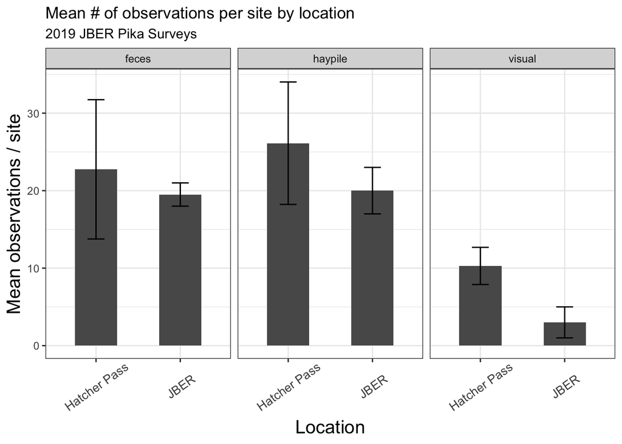

```r
mean.comparison.plot <- ggplot(JBER.HP.mean.summary, aes(x=JBER.HP.mean.summary$Location, y=Obs_Type.length.mean)) +
  geom_bar(stat="identity", width=.5) +
  facet_wrap(~Obs_Type) +
  labs(title="Mean # of observations per site by location",
       subtitle="2019 JBER Pika Surveys") +
  xlab("Location") +
  ylab("Mean observations / site") +
  theme(axis.text.x = element_text(angle=35, vjust=0.6, size = 10),
        axis.title = element_text(size = 15)) +
  geom_errorbar(aes(ymin=Obs_Type.length.mean-Obs_Type.length.std,
                    ymax=Obs_Type.length.mean+Obs_Type.length.std), width = .2)

mean.comparison.plot
```

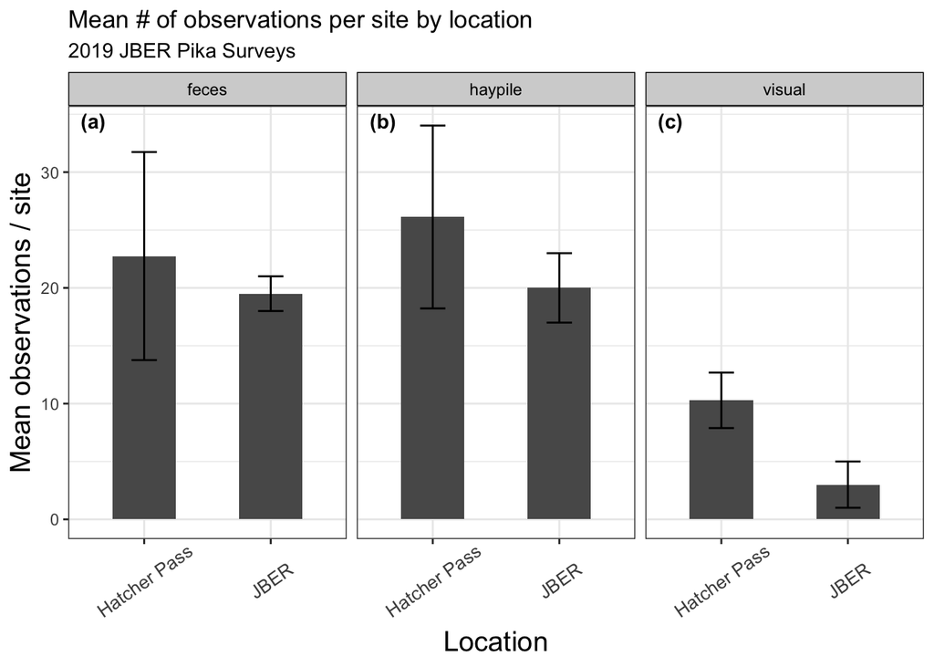

```r
tag_facet(mean.comparison.plot) +
  theme(strip.text = element_text(size = 9, color = "black", margin = margin(t=5, b=5)),
        strip.background = element_rect(fill = "lightgray"))
```